# Report HW4

Tara Boroushaki 93105501

3/8/2018

1. Teacher’s satisfaction was extracted from Teachers Questionnaire question 10 a-g. The mean of answers to each section of the question is calculated, then rounded to give 4 levels of satisfaction. using AOV and t.test it can be shown that satisfied teacher had more successful student.

```r
bst$score=0  # student successfulness :)))))
bst$score=rowMeans(bst[,25:29])

bst_summarise=bst %>% select(idcntry,idschool,idteach,score)


btm_summarise=btg %>% mutate(stisfaction1=as.numeric(btbg10a),stisfaction2=as.numeric(btbg10b),stisfaction3=as.numeric(btbg10c),
                             stisfaction4=as.numeric(btbg10d),stisfaction5=as.numeric(btbg10e),stisfaction6=as.numeric(btbg10f),
                             stisfaction7=as.numeric(btbg10f)) %>% select(idcntry,idschool,idteach,stisfaction1,stisfaction2,
                                                                          stisfaction3,stisfaction4,stisfaction5,stisfaction6,stisfaction7)
btm_summarise$stisfaction=round(rowMeans(btm_summarise[,4:10],na.rm = T) )
btm_summarise=btm_summarise%>%select(idcntry,idschool,idteach,stisfaction)
S_vs_T=merge(bst_summarise,btm_summarise,by=c("idcntry","idschool","idteach"))%>% filter(!is.na(stisfaction))
aov(score ~ stisfaction, data = S_vs_T) -> fit
fit
```

```
## Call:
##    aov(formula = score ~ stisfaction, data = S_vs_T)
##
## Terms:
##                 stisfaction  Residuals
## Sum of Squares      2687087 3432972791
## Deg. of Freedom           1     318208
##
## Residual standard error: 103.8675
## Estimated effects may be unbalanced
```

```r
summary.aov(fit)
```

```
##                 Df    Sum Sq Mean Sq F value Pr(>F)
## stisfaction      1 2.687e+06 2687087   249.1 <2e-16 ***
## Residuals   318208 3.433e+09   10788
## ---
## Signif. codes:  0 '***' 0.001 '**' 0.01 '*' 0.05 '.' 0.1 ' ' 1
```

```r
S_vs_T%>%group_by(stisfaction) %>% summarise(Score=mean(score)) %>%
  hchart(type="bar",hcaes(x = stisfaction, y = Score),name = "")%>%
  hc_title(text = "Q1")%>%
  hc_subtitle(text = "(1=the most satisfied, 4=the least satisfied)")->p1
p1
```

[interactive chart not shown]

```r
g1=S_vs_T %>% filter(stisfaction<3)
g2=S_vs_T %>% filter(stisfaction>2)
t.test(g1$score,g2$score, "less")
```

```
##
##  Welch Two Sample t-test
##
## data:  g1$score and g2$score
## t = 7.1377, df = 26118, p-value = 1
## alternative hypothesis: true difference in means is less than 0
## 95 percent confidence interval:
##      -Inf 6.520542
## sample estimates:
## mean of x mean of y
##  481.3783  476.0790
```

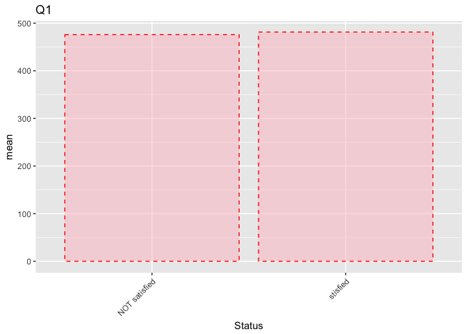

```r
ha1=as.data.frame(c(stisfied = mean(g1$score),NOTsatisfied= mean(g2$score)))
names(ha1)=as.factor(c("mean"))
ha1$group=as.factor(c("stisfied","NOT satisfied"))
p1_=ggplot(ha1,aes(x=group,y=mean))+geom_col(linetype = "dashed",color = "red",fill = "pink",alpha=0.5)+
  xlab("Status")+ylab("mean")+ggtitle("Q1")+theme(axis.text.x = element_text(angle = 45, hjust = 1, vjust = 1))
p1_
```

```r
hchart(density(g1$score), type = "area",name="satisfied") %>% hc_add_series(density(g2$score), type = "area",name="not satisfied")
```

[interactive chart not shown]

2. First, students who didn’t know their parents education level were ommited. mother and father edulation level were added to give a 14 level feature. it can be seen that students who are from educated parents have better math score. To make it clear, the second plot shows the mean of student from families below and above the 7th level.

```r
bsg_summarise=bsg%>%select(idcntry,idschool,idstud,bsbg07a,bsbg07b)%>%filter(!is.na(bsbg07a))%>%filter(!is.na(bsbg07b))%>%
    filter(bsbg07a!=8)%>%filter(bsbg07b!=8)%>%mutate(eduLevel=(as.numeric(bsbg07b)+as.numeric(bsbg07a)))

bst_summarise=bst %>% select(idcntry,idschool,idstud,score)

St_vs_bg=merge(bst_summarise,bsg_summarise,by=c("idcntry","idschool","idstud"))
aov(score ~ eduLevel, data = St_vs_bg) -> fit2
fit2
```

```
## Call:
##    aov(formula = score ~ eduLevel, data = St_vs_bg)
##
## Terms:
##                   eduLevel  Residuals
## Sum of Squares   722581183 4064921958
## Deg. of Freedom          1     425058
##
## Residual standard error: 97.7917
## Estimated effects may be unbalanced
```

```r
summary.aov(fit2)
```

```
##                 Df    Sum Sq   Mean Sq F value Pr(>F)
## eduLevel         1 7.226e+08 722581183   75558 <2e-16 ***
## Residuals   425058 4.065e+09      9563
## ---
## Signif. codes:  0 '***' 0.001 '**' 0.01 '*' 0.05 '.' 0.1 ' ' 1
```

```r
St_vs_bg%>%group_by(eduLevel) %>% summarise(Score=mean(score)) %>%
  hchart(type="bar",hcaes(x = eduLevel, y = Score),name = "")%>%
  hc_title(text = "Q2- Family education Level")%>%
  hc_xAxis(title = list(text = "parent edu level ")) %>%
  hc_subtitle(text = "(the more the higher)") ->p2
p2
```

[interactive chart not shown]

```r
g1=St_vs_bg %>% filter(eduLevel>7)
g2=St_vs_bg %>% filter(eduLevel<=7)
t.test(g1$score,g2$score, "less")
```

```
##
##  Welch Two Sample t-test
##
## data:  g1$score and g2$score
## t = 223.44, df = 407470, p-value = 1
## alternative hypothesis: true difference in means is less than 0
## 95 percent confidence interval:
##      -Inf 69.78123
## sample estimates:
## mean of x mean of y
##  521.4137  452.1424
```

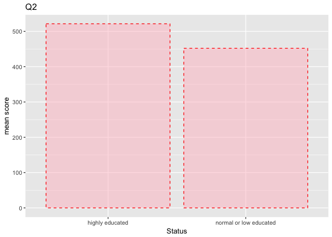

```r
ha1=as.data.frame(c(high = mean(g1$score),low= mean(g2$score)))
names(ha1)=as.factor(c("mean"))
ha1$group=as.factor(c("highly educated","normal or low educated"))
p2_=ggplot(ha1,aes(x=group,y=mean))+geom_col(linetype = "dashed",color = "red",fill = "pink",alpha=0.5)+
  xlab("Status")+ylab("mean score")+ggtitle("Q2")
p2_
```

```r
hchart(density(g1$score), type = "area",name="highly educated") %>% hc_add_series(density(g2$score), type = "area",name="low educated")
```

[interactive chart not shown]

3. the wealth of students’ families was extracted from Students Questionnaire question 6 a-k. The number of “YES” answers are calculated, then rounded to give 11 levels of wealth using AOV and t.test it can be shown that wealthy students had higher math scores.To make it clear, the second plot shows the mean of student from families below and above the 7th level.

```r
bsg_summarise=bsg%>%select(idcntry,idschool,idstud,bsbg06a,bsbg06b,bsbg06c,bsbg06d,bsbg06e,bsbg06f,bsbg06g,bsbg06h,bsbg06i,bsbg06j,bsbg06k)%>%
  mutate(hpos1=as.numeric(bsbg06a)-2,hpos2=as.numeric(bsbg06b)-2,hpos3=as.numeric(bsbg06c)-2,
         hpos4=as.numeric(bsbg06d)-2,hpos5=as.numeric(bsbg06e)-2,hpos6=as.numeric(bsbg06f)-2,
         hpos7=as.numeric(bsbg06g)-2,hpos8=as.numeric(bsbg06h)-2,hpos9=as.numeric(bsbg06i)-2,
         hpos10=as.numeric(bsbg06j)-2,hpos11=as.numeric(bsbg06k)-2)
bsg_summarise=na.omit(bsg_summarise)
bsg_summarise= bsg_summarise %>% mutate(hPosLevel=-(hpos1+hpos2+hpos3+hpos4+hpos5+hpos6+hpos7+hpos8+hpos9+hpos10+hpos11)) %>%
        select(idcntry,idschool,idstud,hPosLevel)

St_vs_bg3=merge(bst_summarise,bsg_summarise,by=c("idcntry","idschool","idstud"))
aov(score ~ hPosLevel, data = St_vs_bg3) -> fit3
fit3
```

```
## Call:
##    aov(formula = score ~ hPosLevel, data = St_vs_bg3)
##
## Terms:
##                  hPosLevel  Residuals
## Sum of Squares   412648274 5174517738
## Deg. of Freedom          1     491797
##
## Residual standard error: 102.5751
## Estimated effects may be unbalanced
```

```r
summary.aov(fit3)
```

```
##                 Df    Sum Sq   Mean Sq F value Pr(>F)
## hPosLevel        1 4.126e+08 412648274   39219 <2e-16 ***
## Residuals   491797 5.175e+09     10522
## ---
## Signif. codes:  0 '***' 0.001 '**' 0.01 '*' 0.05 '.' 0.1 ' ' 1
```

```r
St_vs_bg3%>%group_by(hPosLevel) %>% summarise(Score=mean(score)) %>%
  hchart(type="bar",hcaes(x = hPosLevel, y = Score),name = "")%>%
  hc_title(text = "Q3- home possesions")%>%
  hc_xAxis(title = list(text = "home possesions ")) %>%
  hc_yAxis(title = list(text = "mean Score ")) %>%
  hc_subtitle(text = "(the more, the better)") ->p3
p3
```

[interactive chart not shown]

```r
g1=St_vs_bg3 %>% filter(hPosLevel>7)
g2=St_vs_bg3 %>% filter(hPosLevel<=7)
t.test(g1$score,g2$score, "less")
```

```
##
##  Welch Two Sample t-test
##
## data:  g1$score and g2$score
## t = 140.31, df = 484260, p-value = 1
## alternative hypothesis: true difference in means is less than 0
## 95 percent confidence interval:
##      -Inf 42.36271
## sample estimates:
## mean of x mean of y
##  503.7376  461.8657
```

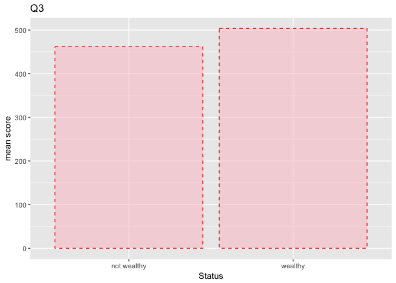

```r
ha1=as.data.frame(c(high = mean(g1$score),low= mean(g2$score)))
names(ha1)=as.factor(c("mean"))
ha1$group=as.factor(c("wealthy","not wealthy"))
p3_=ggplot(ha1,aes(x=group,y=mean))+geom_col(linetype = "dashed",color = "red",fill = "pink",alpha=0.5)+
  xlab("Status")+ylab("mean score")+ggtitle("Q3")
p3_
```

```r
hchart(density(g1$score), type = "area",name="wealthy") %>% hc_add_series(density(g2$score), type = "area",name="not wealthy")
```

[interactive chart not shown]

4. the safety level of schools was extracted from School Questionnaire question 15 f-k. The mean of answers to each section of the question is calculated, then rounded to give 4 levels of safety. Using AOV and t.test it can be shown that students of safer schools had higher math scores.

```r
bcg_summarise=bcg %>%select(idcntry,idschool,bcbg15f,bcbg15g,bcbg15h,bcbg15i,bcbg15j,bcbg15k)%>%
  mutate(peac1=as.numeric(bcbg15f),peac2=as.numeric(bcbg15g),peac3=as.numeric(bcbg15h),
         peac4=as.numeric(bcbg15i),peac5=as.numeric(bcbg15j),peac5=as.numeric(bcbg15k))
bcg_summarise$peace=round(rowMeans(bcg_summarise[,9:13],na.rm = T) )
bcg_summarise=bcg_summarise %>% select(idcntry,idschool,peace) %>% filter(!is.na(peace))


bst_summarise2=bst_summarise %>% group_by(idcntry,idschool) %>% summarise(MScore=mean(score))

St_vs_sch=merge(bst_summarise2,bcg_summarise,by=c("idcntry","idschool"))
aov(MScore ~ peace, data = St_vs_sch) -> fit4
fit4
```

```
## Call:
##    aov(formula = MScore ~ peace, data = St_vs_sch)
##
## Terms:
##                    peace Residuals
## Sum of Squares   5502084  51529937
## Deg. of Freedom        1      7961
##
## Residual standard error: 80.45369
## Estimated effects may be unbalanced
```

```r
summary.aov(fit4)
```

```
##               Df   Sum Sq Mean Sq F value Pr(>F)
## peace          1  5502084 5502084     850 <2e-16 ***
## Residuals   7961 51529937    6473
## ---
## Signif. codes:  0 '***' 0.001 '**' 0.01 '*' 0.05 '.' 0.1 ' ' 1
```

```r
St_vs_sch%>%group_by(peace) %>% summarise(Score=mean(MScore)) %>%
  hchart(type="bar",hcaes(x = peace, y = Score),name = "")%>%
  hc_title(text = "Q4- school saftey")%>%
  hc_xAxis(title = list(text = " school saftey ")) %>%
  hc_yAxis(title = list(text = "mean Score ")) %>%
  hc_subtitle(text = "(the less, the more peacful)") ->p4
p4
```

[interactive chart not shown]

```r
g1=St_vs_sch %>% filter(peace==4 | peace==3)
g2=St_vs_sch %>% filter(peace<3)
t.test(g1$MScore,g2$MScore,"greater")
```

```
##
##  Welch Two Sample t-test
##
## data:  g1$MScore and g2$MScore
## t = -30.524, df = 1130.8, p-value = 1
## alternative hypothesis: true difference in means is greater than 0
## 95 percent confidence interval:
##  -81.77769       Inf
## sample estimates:
## mean of x mean of y
##  405.9154  483.5084
```

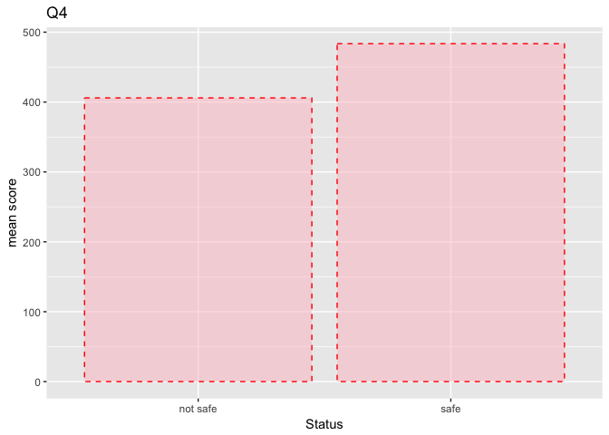

```r
ha1=as.data.frame(c(high = mean(g1$MScore),low= mean(g2$MScore)))
names(ha1)=as.factor(c("mean"))
ha1$group=as.factor(c("not safe","safe"))
p4_=ggplot(ha1,aes(x=group,y=mean))+geom_col(linetype = "dashed",color = "red",fill = "pink",alpha=0.5)+
  xlab("Status")+ylab("mean score")+ggtitle("Q4")
p4_
```

```r
hchart(density(g1$MScore), type = "area",name="not safe") %>% hc_add_series(density(g2$MScore), type = "area",name="safe")
```

[interactive chart not shown]

5. Teachers’ years of experience was extracted from Teachers Questionnaire question btbg01, and their level of education from the same Questionnaire question btbg04.

every 5 years of experience is equivalnet to one level.Generally, experienced teachers’ students have higher mean math Score, but the oldest group of teachers have the lowest mean score of all. probably because it is hard for young students to communicate with old people. To clarify the difference the plot of (mean-350) is shown.

The plots and AOV and t.test confirm that the more educated the teacher is, the higher the mean scores of the students are.

```r
btm_summarise=btg %>% select(idcntry,idschool,idteach,btbg04,year=btbg01)%>%mutate(yearLevel=round(year/5)+1) %>%
        select(idcntry,idschool,idteach,degree=btbg04,yearLevel)
#btm_summarise$yearLevel[which(btm_summarise$yearLevel>6)]=7
bst_summarise2=bst_summarise %>% group_by(idcntry,idschool) %>% summarise(MScore=mean(score))
St_vs_bg5=merge(btm_summarise,bst_summarise2,by=c("idcntry","idschool"))

    ######  year    #######

aov(MScore ~ yearLevel, data = St_vs_bg5) -> fit5
fit5
```

```
## Call:
##    aov(formula = MScore ~ yearLevel, data = St_vs_bg5)
##
## Terms:
##                 yearLevel Residuals
## Sum of Squares     127914  78261655
## Deg. of Freedom         1     12321
##
## Residual standard error: 79.69875
## Estimated effects may be unbalanced
## 975 observations deleted due to missingness
```

```r
summary.aov(fit5)
```

```
##                Df   Sum Sq Mean Sq F value   Pr(>F)
## yearLevel       1   127914  127914   20.14 7.27e-06 ***
## Residuals   12321 78261655    6352
## ---
## Signif. codes:  0 '***' 0.001 '**' 0.01 '*' 0.05 '.' 0.1 ' ' 1
## 975 observations deleted due to missingness
```

```r
St_vs_bg5%>%group_by(yearLevel) %>% summarise(Score=mean(MScore)-350) %>%
  hchart(type="bar",hcaes(x = yearLevel, y = Score),name = "")%>%
  hc_title(text = "Q5- teacher years of exprience")%>%
  hc_xAxis(title = list(text = " teacher years of exprience")) %>%
  hc_yAxis(title = list(text = "[ mean Score -350 ]")) %>%
  hc_subtitle(text = "(the higher the number, the more experience the teaher is)") ->p5
p5
```

[interactive chart not shown]

```r
g1=St_vs_bg5 %>% filter(yearLevel>3 & yearLevel<11)
g2=St_vs_bg5 %>% filter(yearLevel<4)
t.test(g1$MScore,g2$MScore,"less")
```

```
##
##  Welch Two Sample t-test
##
## data:  g1$MScore and g2$MScore
## t = 3.268, df = 11799, p-value = 0.9995
## alternative hypothesis: true difference in means is less than 0
## 95 percent confidence interval:
##      -Inf 7.114287
## sample estimates:
## mean of x mean of y
##  490.8485  486.1163
```

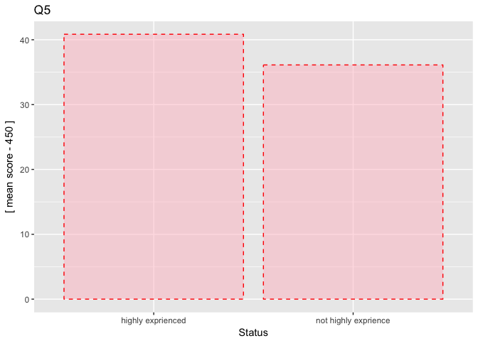

```r
ha1=as.data.frame(c(high = mean(g1$MScore)-450,low= mean(g2$MScore)-450))
names(ha1)=as.factor(c("mean"))
ha1$group=as.factor(c("highly exprienced","not highly exprience"))
p5_=ggplot(ha1,aes(x=group,y=mean))+geom_col(linetype = "dashed",color = "red",fill = "pink",alpha=0.5)+
  xlab("Status")+ylab("[ mean score - 450 ]")+ggtitle("Q5")
p5_
```

```r
hchart(density(as.numeric(g1$MScore)), type = "area",name="highly exprience") %>% hc_add_series(density(as.numeric(g2$MScore)), type = "area",name="not highly exprience")
```

[interactive chart not shown]

```r
    ######  degree    #######

aov(MScore ~ degree, data = St_vs_bg5) -> fit5_1
fit5_1
```

```
## Call:
##    aov(formula = MScore ~ degree, data = St_vs_bg5)
##
## Terms:
##                   degree Residuals
## Sum of Squares   4667281  69379962
## Deg. of Freedom        1     11827
##
## Residual standard error: 76.59135
## Estimated effects may be unbalanced
## 1469 observations deleted due to missingness
```

```r
summary.aov(fit5_1)
```

```
##                Df   Sum Sq Mean Sq F value Pr(>F)
## degree          1  4667281 4667281   795.6 <2e-16 ***
## Residuals   11827 69379962    5866
## ---
## Signif. codes:  0 '***' 0.001 '**' 0.01 '*' 0.05 '.' 0.1 ' ' 1
## 1469 observations deleted due to missingness
```

```r
St_vs_bg5%>%group_by(degree) %>% summarise(Score=mean(MScore)) %>%
  hchart(type="bar",hcaes(x = degree, y = Score),name = "")%>%
  hc_title(text = "Q5- teacher's degree")%>%
  hc_xAxis(title = list(text = " teacher degree ")) %>%
  hc_yAxis(title = list(text = "[ mean Score ]")) %>%
  hc_subtitle(text = "(the higher, the more educated the teaher is)") ->p5_2
p5_2
```

[interactive chart not shown]

```r
g1=St_vs_bg5 %>% filter(degree<4)
g2=St_vs_bg5 %>% filter(degree>3)
t.test(g1$MScore,g2$MScore,"greater")
```

```
##
##  Welch Two Sample t-test
##
## data:  g1$MScore and g2$MScore
## t = -22.136, df = 427.94, p-value = 1
## alternative hypothesis: true difference in means is greater than 0
## 95 percent confidence interval:
##  -85.05341       Inf
## sample estimates:
## mean of x mean of y
##  414.6811  493.8397
```

[figure not shown]

```r
ha1=as.data.frame(c(high = mean(g1$MScore),low= mean(g2$MScore)))
names(ha1)=as.factor(c("mean"))
ha1$group=as.factor(c("highly educated","not highly educated"))
p5_3=ggplot(ha1,aes(x=group,y=mean))+geom_col(linetype = "dashed",color = "red",fill = "pink",alpha=0.5)+
  xlab("Status")+ylab("[ mean score ]")+ggtitle("Q5- teacher degree")
p5_3
```

```r
hchart(density(g1$MScore), type = "area",name="highly educated") %>% hc_add_series(density(g2$MScore), type = "area",name="not highly educated")
```

[interactive chart not shown]

6. Due to test result, boys do not have higher gardes in geometry. The t.test shows that girls has achieved higher mean geometry score.

```r
bst_summarise6=bst %>% mutate(geoScore=(bsmgeo01+bsmgeo02+bsmgeo03+bsmgeo04+bsmgeo05)/5) %>% select(idcntry,idschool,idstud,geoScore )

bsg_summarise2=bsg%>%select(idcntry,idschool,idstud,itsex)
St_vs_bg6=merge(bst_summarise6,bsg_summarise2,by=c("idcntry","idschool","idstud"))
St_vs_bg6=na.omit(St_vs_bg6)
aov(geoScore ~ itsex, data = St_vs_bg6) -> fit6
fit6
```

```
## Call:
##    aov(formula = geoScore ~ itsex, data = St_vs_bg6)
##
## Terms:
##                      itsex  Residuals
## Sum of Squares     1417989 8072867653
## Deg. of Freedom          1     694783
##
## Residual standard error: 107.7927
## Estimated effects may be unbalanced
```

```r
summary.aov(fit6)
```

```
##                 Df    Sum Sq Mean Sq F value Pr(>F)
## itsex            1 1.418e+06 1417989     122 <2e-16 ***
## Residuals   694783 8.073e+09   11619
## ---
## Signif. codes:  0 '***' 0.001 '**' 0.01 '*' 0.05 '.' 0.1 ' ' 1
```

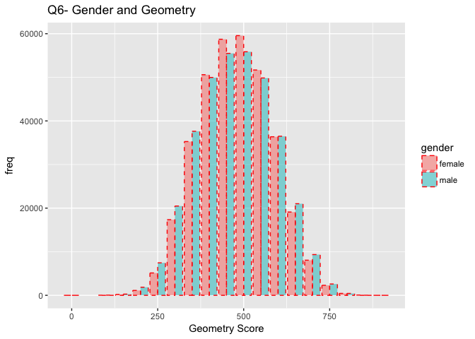

```r
St_vs_bg6%>%mutate(ScorePlot=round(geoScore/50)*50)%>%group_by(itsex,ScorePlot)%>%summarise(num=n())->exp6
exp6=na.omit(exp6)
exp6$gender=""
exp6$gender[which(exp6$itsex==1)]="female"
exp6$gender[which(exp6$itsex==2)]="male"
p6_=ggplot(exp6,aes(x=ScorePlot,y=num))+
  geom_bar(aes(fill = gender),stat = "identity",position = "dodge",linetype = "dashed",color = "red",alpha=0.5)+
  xlab("Geometry Score")+ylab("freq")+ggtitle("Q6- Gender and Geometry")
p6_
```

```r
g1=St_vs_bg6 %>% filter(itsex==1)
g2=St_vs_bg6 %>% filter(itsex==2)
t.test(g1$geoScore,g2$geoScore,"less")
```

```
##
##  Welch Two Sample t-test
##
## data:  g1$geoScore and g2$geoScore
## t = 11.049, df = 693480, p-value = 1
## alternative hypothesis: true difference in means is less than 0
## 95 percent confidence interval:
##      -Inf 3.282566
## sample estimates:
## mean of x mean of y
##  479.6830  476.8258
```

```r
ha1=as.data.frame(c(female = mean(g1$geoScore)-450,male= mean(g2$geoScore)-450))
names(ha1)=as.factor(c("mean"))
ha1$group=as.factor(c("female","male"))

ha1 %>% hchart(type="bar",hcaes(x = group, y = mean),name = "")%>%
  hc_title(text = "Q6- Gender and Geometry")%>%
  hc_xAxis(title = list(text = " Gender ")) %>%
  hc_yAxis(title = list(text = "[ mean Geometry Score - 450]")) ->p6
p6
```

[interactive chart not shown]

```r
hchart(density(g1$geoScore), type = "area",name="female") %>% hc_add_series(density(g2$geoScore), type = "area",name="male")
```

[interactive chart not shown]

7. For this question, whether or not the student eats breakfast in the morning relation with math score is evalutaed. Question 12 from Students Questionnaire is used for this purpose. Due to the tests and plots, student who always or almost always eat well in the morning have higher mean math scores. (the smaller the number, the better the eatung habits are)

```r
bst_summarise=bst %>% select(idcntry,idschool,idstud,score)

bsg_summarise7=bsg%>%select(idcntry,idschool,idstud,bsbg12)

St_vs_bg7=merge(bst_summarise,bsg_summarise7,by=c("idcntry","idschool","idstud"))
St_vs_bg7=na.omit(St_vs_bg7)
aov(score ~ bsbg12, data = St_vs_bg7) -> fit7
fit7
```

```
## Call:
##    aov(formula = score ~ bsbg12, data = St_vs_bg7)
##
## Terms:
##                     bsbg12  Residuals
## Sum of Squares    69405842 7401755423
## Deg. of Freedom          1     685851
##
## Residual standard error: 103.8849
## Estimated effects may be unbalanced
```

```r
summary.aov(fit7)
```

```
##                 Df    Sum Sq  Mean Sq F value Pr(>F)
## bsbg12           1 6.941e+07 69405842    6431 <2e-16 ***
## Residuals   685851 7.402e+09    10792
## ---
## Signif. codes:  0 '***' 0.001 '**' 0.01 '*' 0.05 '.' 0.1 ' ' 1
```

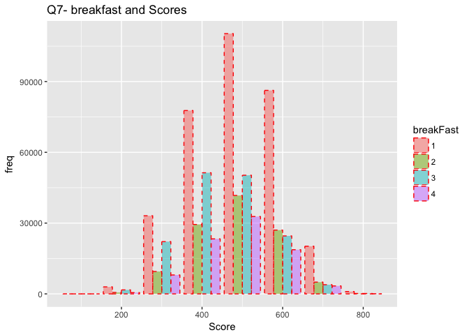

```r
St_vs_bg7%>%mutate(ScorePlot=round(score/100)*100,breakFast=as.factor(bsbg12))%>%group_by(breakFast,ScorePlot)%>%summarise(num=n())->exp7
exp7=na.omit(exp7)
p6_=ggplot(exp7,aes(x=ScorePlot,y=num))+
  geom_bar(aes(fill = breakFast),stat = "identity",position = "dodge",linetype = "dashed",color = "red",alpha=0.5)+
  xlab("Score")+ylab("freq")+ggtitle("Q7- breakfast and Scores")
p6_
```

```r
g1=St_vs_bg7 %>% filter(bsbg12<3)
g2=St_vs_bg7 %>% filter(bsbg12>2)
t.test(g1$score,g2$score, "less")
```

```
##
##  Welch Two Sample t-test
##
## data:  g1$score and g2$score
## t = 102.84, df = 517790, p-value = 1
## alternative hypothesis: true difference in means is less than 0
## 95 percent confidence interval:
##      -Inf 26.93575
## sample estimates:
## mean of x mean of y
##  491.9433  465.4316
```

```r
ha1=as.data.frame(c(w1 = mean(g1$score),w2= mean(g2$score)))
names(ha1)=as.factor(c("mean"))
ha1$group=as.factor(c("usually eat breakfast","usually don't eat breakfast"))

ha1 %>% hchart(type="bar",hcaes(x = group, y = mean),name = "")%>%
  hc_title(text = "Q7- breakfast and Scores")%>%
  hc_xAxis(title = list(text = " breakfast ")) %>%
  hc_yAxis(title = list(text = "mean Score")) ->p7
p7
```

[interactive chart not shown]

```r
hchart(density(g1$score), type = "area",name="usually eat breakfast") %>% hc_add_series(density(g2$score), type = "area",name="usually don't eat breakfast")
```

[interactive chart not shown]

- suggest 3 other questions *
1. Does the time which students spend at school play a role in their scores? It can be understood that spending too much or too low amount of hours at school have a bad effect on scores. The optimum is about 1000 hours each year.

```r
bst_summarise8=bst %>% select(idcntry,idschool,score)%>%group_by(idcntry,idschool)%>%
  summarise(MScore=mean(score,na.rm = T))
bcg_summarise8=bcg %>% select(idcntry,idschool,hour=bcbg07b,dayYear=bcbg07a)%>%
  mutate(time=(hour/60)*dayYear)%>%select(idcntry,idschool,time)

S_vs_Sch8=merge(bst_summarise8,bcg_summarise8,by=c("idcntry","idschool"))
S_vs_Sch8=na.omit(S_vs_Sch8)
aov(MScore ~ time, data = S_vs_Sch8) -> fit8
fit8
```

```
## Call:
##    aov(formula = MScore ~ time, data = S_vs_Sch8)
##
## Terms:
##                     time Residuals
## Sum of Squares    625026  50490298
## Deg. of Freedom        1      7134
##
## Residual standard error: 84.12739
## Estimated effects may be unbalanced
```

```r
summary.aov(fit8)
```

```
##               Df   Sum Sq Mean Sq F value Pr(>F)
## time           1   625026  625026   88.31 <2e-16 ***
## Residuals   7134 50490298    7077
## ---
## Signif. codes:  0 '***' 0.001 '**' 0.01 '*' 0.05 '.' 0.1 ' ' 1
```

```r
S_vs_Sch8%>%mutate(time2=round(time/50)*50)%>%group_by(time2)%>%summarise(Score=mean(MScore))%>%
  hchart(type="bar",hcaes(x = time2, y = Score),name = "")%>%
  hc_title(text = "Q8- school hours")->p8
p8
```

[interactive chart not shown]

```r
g1=S_vs_Sch8 %>% filter(time>1200)
g2=S_vs_Sch8 %>% filter(time<1200)
t.test(g1$MScore,g2$MScore, "greater")
```

```
##
##  Welch Two Sample t-test
##
## data:  g1$MScore and g2$MScore
## t = -11.641, df = 1492.9, p-value = 1
## alternative hypothesis: true difference in means is greater than 0
## 95 percent confidence interval:
##  -38.73894       Inf
## sample estimates:
## mean of x mean of y
##  451.3954  485.3355
```

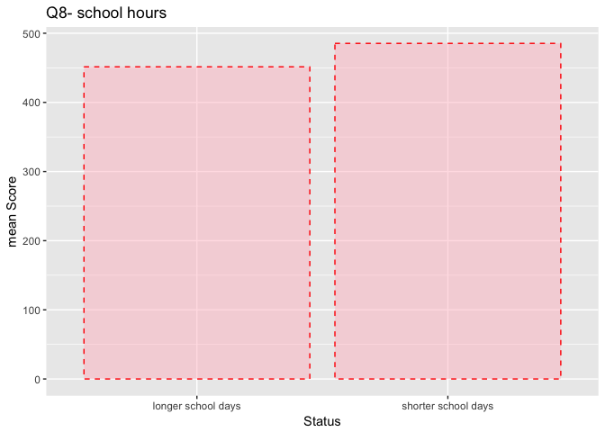

```r
ha1=as.data.frame(c(time = mean(g1$MScore),time= mean(g2$MScore)))
names(ha1)=as.factor(c("mean"))
ha1$group=as.factor(c("longer school days","shorter school days"))
p8_=ggplot(ha1,aes(x=group,y=mean))+geom_col(linetype = "dashed",color = "red",fill = "pink",alpha=0.5)+
  xlab("Status")+ylab("mean Score")+ggtitle("Q8- school hours")
p8_
```

```r
hchart(density(g1$MScore), type = "area",name="longer school days") %>% hc_add_series(density(g2$MScore), type = "area",name="shorter school days")
```

[interactive chart not shown]

2. Making friends and learning how to socialize are the main reason that student are sent to schools. In question 15 of Students Questionnaire, student are asked how much they agree with “I like to see my classmates at school”. The test results show that students who agree are agree a littel, have higher mean score than those who disagree. It is noteworthy to mention that students who choosed “agree a littel” have the highest mean score of all.

```r
bst_summarise9=bst %>% select(idcntry,idschool,idstud,score)
bsg_summarise9=bsg%>%select(idcntry,idschool,idstud,friend=bsbg15d)

S_vs_bg9=merge(bst_summarise9,bsg_summarise9,by=c("idcntry","idschool","idstud"))
S_vs_bg9=na.omit(S_vs_bg9)
aov(score ~ friend, data = S_vs_bg9) -> fit9
fit9
```

```
## Call:
##    aov(formula = score ~ friend, data = S_vs_bg9)
##
## Terms:
##                     friend  Residuals
## Sum of Squares    12026379 7303178633
## Deg. of Freedom          1     679374
##
## Residual standard error: 103.6816
## Estimated effects may be unbalanced
```

```r
summary.aov(fit9)
```

```
##                 Df    Sum Sq  Mean Sq F value Pr(>F)
## friend           1 1.203e+07 12026379    1119 <2e-16 ***
## Residuals   679374 7.303e+09    10750
## ---
## Signif. codes:  0 '***' 0.001 '**' 0.01 '*' 0.05 '.' 0.1 ' ' 1
```

```r
S_vs_bg9%>%group_by(friend)%>%summarise(Score=mean(score))%>%
  hchart(type="bar",hcaes(x = friend, y = Score),name = "")%>%
  hc_title(text = "Q9- liking to see friends and score")%>%
  hc_xAxis(title = list(text = " socializing ")) %>%
  hc_yAxis(title = list(text = "[ mean Geometry Score]"))%>%
  hc_subtitle(text = "(the higher, the less likley to have friends)")->p9
p9
```

[interactive chart not shown]

```r
g1=S_vs_bg9 %>% filter(as.numeric(friend)<3)
g2=S_vs_bg9 %>% filter(as.numeric(friend)>2)
t.test(g1$score,g2$score, "greater")
```

```
##
##  Welch Two Sample t-test
##
## data:  g1$score and g2$score
## t = 69.615, df = 63911, p-value < 2.2e-16
## alternative hypothesis: true difference in means is greater than 0
## 95 percent confidence interval:
##  31.8198     Inf
## sample estimates:
## mean of x mean of y
##  486.3487  453.7589
```

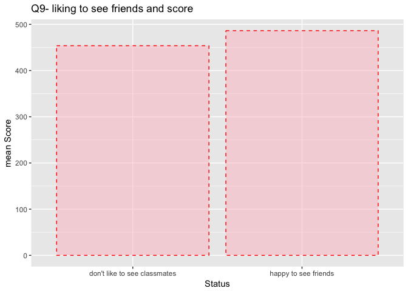

```r
ha1=as.data.frame(c(time = mean(g1$score),time= mean(g2$score)))
names(ha1)=as.factor(c("mean"))
ha1$group=as.factor(c("happy to see friends","don't like to see classmates"))
p8_=ggplot(ha1,aes(x=group,y=mean))+geom_col(linetype = "dashed",color = "red",fill = "pink",alpha=0.5)+
  xlab("Status")+ylab("mean Score")+ggtitle("Q9- liking to see friends and score")
p8_
```

```r
hchart(density(g1$score), type = "area",name="happy to see friends") %>% hc_add_series(density(g2$score), type = "area",name="don't like to see classmates")
```

[interactive chart not shown]

3.Learning mathematics for more job opportunities: In question 20-g of Students Questionnaire, they are asked how much they agree that mathematic is important to get a job in future. The test indicate that the students’ idea about this question is important. However, by investigating the first plot, it is noteable that only those who completely disagree the notion that math is important to get job in future has a significantly lower mean score.

```r
bst_summarise9=bst %>% select(idcntry,idschool,idstud,score)
bsg_summarise9=bsg%>%select(idcntry,idschool,idstud,Job=bsbm20g)

S_vs_bg10=merge(bst_summarise9,bsg_summarise9,by=c("idcntry","idschool","idstud"))
S_vs_bg10=na.omit(S_vs_bg10)
aov(score ~ Job, data = S_vs_bg10) -> fit10
fit10
```

```
## Call:
##    aov(formula = score ~ Job, data = S_vs_bg10)
##
## Terms:
##                        Job  Residuals
## Sum of Squares    23865875 7232525778
## Deg. of Freedom          1     676155
##
## Residual standard error: 103.4241
## Estimated effects may be unbalanced
```

```r
summary.aov(fit10)
```

```
##                 Df    Sum Sq  Mean Sq F value Pr(>F)
## Job              1 2.387e+07 23865875    2231 <2e-16 ***
## Residuals   676155 7.233e+09    10697
## ---
## Signif. codes:  0 '***' 0.001 '**' 0.01 '*' 0.05 '.' 0.1 ' ' 1
```

```r
S_vs_bg10%>%group_by(Job)%>%summarise(Score=mean(score))%>%
  hchart(type="bar",hcaes(x = Job, y = Score),name = "")%>%
  hc_title(text = "Q10- math for job")%>%
  hc_xAxis(title = list(text = " how imp is math for job? ")) %>%
  hc_yAxis(title = list(text = "[ mean Score]"))%>%
  hc_subtitle(text = "(the higher, the less likley to be important for future job)")->p10
p10
```

[interactive chart not shown]

```r
g1=S_vs_bg10 %>% filter(as.numeric(Job)<3)
g2=S_vs_bg10 %>% filter(as.numeric(Job)>2)
t.test(g1$score,g2$score, "greater")
```

```
##
##  Welch Two Sample t-test
##
## data:  g1$score and g2$score
## t = 61.473, df = 116930, p-value < 2.2e-16
## alternative hypothesis: true difference in means is greater than 0
## 95 percent confidence interval:
##  22.63912      Inf
## sample estimates:
## mean of x mean of y
##  487.2770  464.0154
```

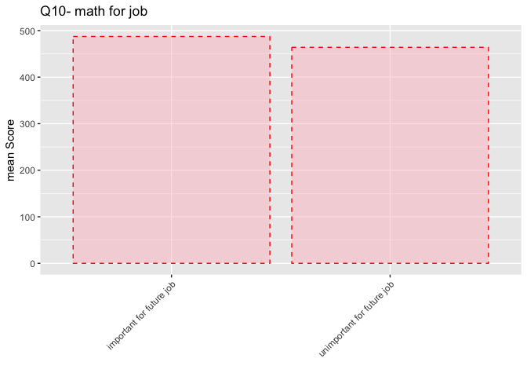

```r
ha1=as.data.frame(c(time = mean(g1$score),time= mean(g2$score)))
names(ha1)=as.factor(c("mean"))
ha1$group=as.factor(c("important for future job","unimportant for future job"))
p10_=ggplot(ha1,aes(x=group,y=mean))+geom_col(linetype = "dashed",color = "red",fill = "pink",alpha=0.5)+
  xlab("")+ylab("mean Score")+ggtitle("Q10- math for job")+theme(axis.text.x = element_text(angle = 45, hjust = 1, vjust = 1))
p10_
```

```r
hchart(density(g1$score), type = "area",name="important for future job") %>% hc_add_series(density(g2$score), type = "area",name="unimportant for future job")
```

[interactive chart not shown]